# Matching stage of the analysis

Matching analysis based on material found on internet, specially with modified codes from: https://www.practicalpropensityscore.com

We first get the data for our study

```r
raw_df <- subset(raw_df, select = -c(trimmed_languages))ß
```

```
Error: unexpected symbol in "raw_df <- subset(raw_df, select = -c(trimmed_languages))ß"
```

We change the categorical values into numerical factors

[output not shown]

```r
head(df) # Cases = 1, controls = 0
```

# PROPENSITY SCORE ESTIMATION

```r
print(ps_formula)
```

```
MS.NonMS ~ velocity_mean_start + size + main_language + n_languages +
    creation_year + n_commits + n_issues + n_contributors
```

PS calculated through Logistic Regression

```r
summary(ps_model)
```

```
Call:
glm(formula = ps_formula, family = binomial(), data = df)

Coefficients:
                      Estimate Std. Error z value Pr(>|z|)
(Intercept)         -4.573e-01  1.515e+00  -0.302   0.7628
velocity_mean_start  7.454e-03  4.044e-03   1.843   0.0653 .
size                -7.484e-07  2.122e-06  -0.353   0.7244
main_language2      -1.658e+01  1.379e+03  -0.012   0.9904
main_language3      -3.698e-01  1.591e+00  -0.232   0.8162
main_language4      -1.669e+01  1.379e+03  -0.012   0.9903
main_language5      -1.712e+01  2.400e+03  -0.007   0.9943
main_language6       1.597e+01  2.400e+03   0.007   0.9947
main_language7      -1.652e+01  2.400e+03  -0.007   0.9945
main_language8      -1.828e+00  1.594e+00  -1.147   0.2514
main_language9      -6.078e-01  1.559e+00  -0.390   0.6966
main_language10     -1.220e+00  1.536e+00  -0.794   0.4272
main_language11     -9.650e-01  1.591e+00  -0.606   0.5442
main_language12     -1.422e+00  1.513e+00  -0.940   0.3473
main_language13     -2.899e+00  1.846e+00  -1.570   0.1164
main_language14     -4.828e-02  1.857e+00  -0.026   0.9793
main_language15     -7.470e-01  1.996e+00  -0.374   0.7082
main_language16     -2.198e+00  1.871e+00  -1.175   0.2401
main_language17     -1.663e+01  2.400e+03  -0.007   0.9945
main_language18     -2.116e+00  1.612e+00  -1.313   0.1893
n_languages          8.161e-02  1.082e-01   0.754   0.4507
creation_year2      -6.502e-01  5.356e-01  -1.214   0.2247
creation_year3      -1.320e-01  4.755e-01  -0.278   0.7813
creation_year4       4.574e-02  5.135e-01   0.089   0.9290
creation_year5       5.631e-01  5.726e-01   0.983   0.3254
n_commits            5.124e-05  1.753e-04   0.292   0.7701
n_issues            -1.846e-04  7.899e-04  -0.234   0.8152
n_contributors       1.591e-02  1.508e-02   1.055   0.2914
---
Signif. codes:  0 ‘***’ 0.001 ‘**’ 0.01 ‘*’ 0.05 ‘.’ 0.1 ‘ ’ 1

(Dispersion parameter for binomial family taken to be 1)

    Null deviance: 278.5  on 264  degrees of freedom
Residual deviance: 244.3  on 237  degrees of freedom
AIC: 300.3

Number of Fisher Scoring iterations: 15
```

PS calculated through Random Forests - The number of trees: The state-of-the-art suggests that the number of variables to be considered in each tree should be the sqrt(num_variables)

```r
summary(df$logitPScoresRF[df$MS.NonMS==0])
```

```
   Min. 1st Qu.  Median    Mean 3rd Qu.    Max.
-2.8367 -1.8777 -1.5774 -1.5840 -1.2552 -0.2105
```

Estimate propensity scores with generalized boosted modeling (GBM)

- Number of trees is defined as based on the state-of-the-art, most likely we may not need that amount to reach rhe maxima.
- The interction depth follows the same logic of variable interaction as with the random forest
- Stoping criteria: Looking for covariate balance, we look for maximum effect size of the of the matches, defore minimizing the difference between means across treatment and control observations.
- estimand: We are estimating the ATT (for the average treatment effect of the treated)

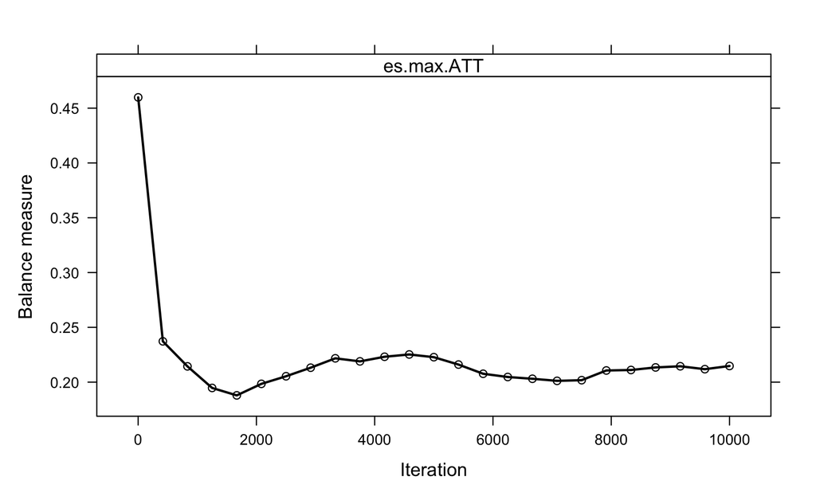

Obtain summary statistics of common support for propensity scores estimated with the first imputed dataset

```r
#obtain proportion of treated cases above maximum control cases
#and proportion of control cases below minum treated cases
#for logistic regression
with(df, 100*c(
  mean(as.numeric(df$logitPScores[df$MS.NonMS==1] > max(df$logitPScores[df$MS.NonMS==0]))),
  mean(as.numeric(df$logitPScores[df$MS.NonMS==0] < min(df$logitPScores[df$MS.NonMS==1])))))
```

```
[1] 5.172414 4.347826
```

Ploting whiskers plots and density histograms for the propensity scores

```r
#evaluate common support with box and whiskers plot
df$MS.NonMS = factor(df$MS.NonMS)
library(lattice)
lattice.options(default.theme = standard.theme(color = FALSE))

bwplot( df$logitPScores~df$MS.NonMS, data = df,  ylab = "Propensity Scores", xlab = "Treatment",auto.key = TRUE)

bwplot( df$logitPScoresRF~df$MS.NonMS ,  data = df,  ylab = "Propensity Scores", xlab = "Treatment",auto.key = TRUE)

bwplot( df$pScoresGBM~df$MS.NonMS,  data = df,  ylab = "Propensity Scores", xlab = "Treatment",auto.key = TRUE)

#evaluate common support with kernel density plots
require(lattice)
lattice.options(default.theme = standard.theme(color = FALSE))

densityplot( ~df$logitPScores, groups=df$MS.NonMS, plot.points=F, xlim=c(0,1), lwd=2,
             data = df,  ylab = "Propensity Scores", xlab = "Treatment",auto.key = TRUE)

densityplot( ~df$logitPScoresRF, groups=df$MS.NonMS, plot.points=F, xlim=c(0,1), lwd=2,
             data = df,  ylab = "Propensity Scores", xlab = "Treatment",auto.key = TRUE)

densityplot( ~df$pScoresGBM, groups=df$MS.NonMS, plot.points=F, xlim=c(0,1), lwd=2,
             data = df,  ylab = "Propensity Scores", xlab = "Treatment",auto.key = TRUE)
```

[output not shown]

# ONE-2-ONE GREEDY MATCHING

## With Logistic regression scores

- distance: The propensity scores estimated through the different three techniques.
- caliper: Is the maximum distance we consider as acceptable for any match, if it exceeds this, then it means that the matching is too light
- ratio: Considered ratio of controls per treatment cases.
- Replacement: We use it to have more than one matching opportunity

Standardized mean differences below 0.25 are accepted as set by the caliper. Therefore, the caliper worked and we are having reasonable covariate balance. In theory.

```r
summary(model.greedyMatching)
```

```
Call:
svyglm(formula = velocity_mean_end ~ MS.NonMS, design = design.greedyMatching,
    family = gaussian())

Survey design:
svydesign(ids = ~1, weights = ~weights, data = data.greedyMatching)

Coefficients:
            Estimate Std. Error t value Pr(>|t|)
(Intercept)   30.621      6.530   4.689 8.79e-06 ***
MS.NonMS       2.463      8.904   0.277    0.783
---
Signif. codes:  0 ‘***’ 0.001 ‘**’ 0.01 ‘*’ 0.05 ‘.’ 0.1 ‘ ’ 1

(Dispersion parameter for gaussian family taken to be 1845.244)

Number of Fisher Scoring iterations: 2
```

## With Random Forest scores

- Worse results than with Logistic Regression.

```r
summary(model.greedyMatching)
```

```
Call:
svyglm(formula = velocity_mean_end ~ MS.NonMS, design = design.greedyMatching,
    family = gaussian())

Survey design:
svydesign(ids = ~1, weights = ~weights, data = data.greedyMatching)

Coefficients:
            Estimate Std. Error t value Pr(>|t|)
(Intercept)   21.710      8.037   2.701  0.00863 **
MS.NonMS      11.029     10.141   1.088  0.28046
---
Signif. codes:  0 ‘***’ 0.001 ‘**’ 0.01 ‘*’ 0.05 ‘.’ 0.1 ‘ ’ 1

(Dispersion parameter for gaussian family taken to be 1811.578)

Number of Fisher Scoring iterations: 2
```

## With Generalized Boosted Modeling

- Useless, we cannot work with the 1:1 matching here, it’s too rigid

```r
#diagnose covariate balance
(balance.greedyMatching <- summary(greedyMatching, standardize=T))
```

```
Call:
matchit(formula = ps_formula, data = df, method = "nearest",
    distance = df$pScoresGBM, replace = T, caliper = 0.25, ratio = 1)

Summary of Balance for All Data:
                    Means Treated Means Control Std. Mean Diff. Var. Ratio eCDF Mean eCDF Max
distance                   0.7640        0.0661          5.1021     4.9921    0.5000   1.0000
velocity_mean_start       32.3412       21.7393          0.2063     2.8749    0.0413   0.1031
size                   27075.2931    34812.0242         -0.0795     0.6750    0.0787   0.1419
main_language1             0.0172        0.0048          0.0953          .    0.0124   0.0124
main_language2             0.0000        0.0145         -0.1372          .    0.0145   0.0145
main_language3             0.1034        0.0386          0.2128          .    0.0648   0.0648
main_language4             0.0000        0.0145         -0.1372          .    0.0145   0.0145
main_language5             0.0000        0.0048         -0.0788          .    0.0048   0.0048
main_language6             0.0172        0.0000          0.1325          .    0.0172   0.0172
main_language7             0.0000        0.0048         -0.0788          .    0.0048   0.0048
main_language8             0.0690        0.1256         -0.2235          .    0.0566   0.0566
main_language9             0.1379        0.0676          0.2039          .    0.0703   0.0703
main_language10            0.1897        0.1739          0.0402          .    0.0157   0.0157
main_language11            0.1034        0.0580          0.1493          .    0.0455   0.0455
main_language12            0.2241        0.2657         -0.0997          .    0.0416   0.0416
main_language13            0.0172        0.0773         -0.4613          .    0.0601   0.0601
main_language14            0.0345        0.0097          0.1360          .    0.0248   0.0248
main_language15            0.0172        0.0097          0.0582          .    0.0076   0.0076
main_language16            0.0172        0.0290         -0.0902          .    0.0117   0.0117
main_language17            0.0000        0.0048         -0.0788          .    0.0048   0.0048
main_language18            0.0517        0.0966         -0.2027          .    0.0449   0.0449
n_languages                3.3966        3.1014          0.1361     1.8375    0.0240   0.0563
creation_year1             0.2069        0.2077         -0.0021          .    0.0008   0.0008
creation_year2             0.1379        0.2415         -0.3005          .    0.1036   0.1036
creation_year3             0.2586        0.2609         -0.0051          .    0.0022   0.0022
creation_year4             0.2069        0.1932          0.0337          .    0.0137   0.0137
creation_year5             0.1897        0.0966          0.2373          .    0.0930   0.0930
n_commits                569.4310      511.8696          0.0824     0.5872    0.0394   0.1357
n_issues                 186.6724      193.2705         -0.0241     1.1909    0.0462   0.1341
n_contributors            11.8103        9.4203          0.1488     2.0243    0.0333   0.1155

Summary of Balance for Matched Data:
                    Means Treated Means Control Std. Mean Diff. Var. Ratio eCDF Mean eCDF Max
distance                   0.3118        0.3019               .          .         .        .
```

[output cut: 52 more lines]

```
creation_year1                    0
creation_year2                    0
creation_year3                    0
creation_year4                    0
creation_year5                    0
n_commits                         .
n_issues                          .
n_contributors                    .

Sample Sizes:
          Control Treated
All           207      58
Matched         1       1
Unmatched     206      57
Discarded       0       0
```

# VARIABLE RATIO GREEDY MATCHING

## With logistic propensity scores

For the Match function: - M: The nunmber of matches - ties: We specify that if there are multiple matches between controls towards one treatment, we accept it

```r
library(Matching) #load necessary package

#Maching requires the treatment indicator to be logical (TRUE/FALSE)
df$MS.NonMS <- ifelse(df$MS.NonMS==1, TRUE,FALSE)

greedyMatching2 <- with(df,
                        Match(Y=velocity_mean_end, Tr=MS.NonMS, X=logitPScores,
                              estimand = "ATT", M = 1,
                              caliper = 0.25, replace=TRUE, ties=TRUE))

#evaluate covariate balance
balance.greedyMatching2 <- MatchBalance(ps_formula, data = df, match.out = greedyMatching2,
                                        ks = F, paired=F)
balance.greedyMatching2After <- unlist(balance.greedyMatching2$AfterMatching)
#summarize only the standized mean differences (they have been multiplied by 100, so I divided by 100)
#see details in ?balanceUV
summary(abs(balance.greedyMatching2After[names(balance.greedyMatching2After)=="sdiff"]/100))
table(abs(balance.greedyMatching2After[names(balance.greedyMatching2After)=="sdiff"]/100)>0.1)


#-------------------------
#estimate ATT with variable ratio greedy matching
#with replacement and within 0.25 caliper
#standard error is obtained with Abadie and Imbens (2006) estimator
summary(greedyMatching2) # Pff the performed matching is completely far from being statistically
# significant.

#=======================================
#Rosenbaum Sensitivity Test for Wilcoxon Signed Rank P-Value
#with genetic matching
library(rbounds)

psens(x=greedyMatching2$mdata$X, y = greedyMatching2$mdata$Y, Gamma=3, GammaInc=.1)
# The p values are completely non significant, indeed the progression starts already being 1.
```

[output not shown]

## With Random Forests propensity scores

```r
#-------------------------
#estimate ATT with variable ratio greedy matching
#with replacement and within 0.25 caliper
#standard error is obtained with Abadie and Imbens (2006) estimator
summary(greedyMatching2)
```

```
Estimate...  10.864
AI SE......  15.409
T-stat.....  0.70502
p.val......  0.4808

Original number of observations..............  265
Original number of treated obs...............  58
Matched number of observations...............  55
Matched number of observations  (unweighted).  56

Caliper (SDs)........................................   0.25
Number of obs dropped by 'exact' or 'caliper'  3
```

## With GBM propensity scores

```r
#evaluate covariate balance
balance.greedyMatching2 <- MatchBalance(ps_formula, data = df, match.out = greedyMatching2,
                                        ks = F, paired=F)
```

[output not shown]

# GENETIC MATCHING WITH PROPENSITY SCORES + COVARIATES

## With logistic propensity scores

For the Match function: - ties: It’s greedy matching as we account for more controls per treat cases.

```r
psens(geneticMatching$mdata$X, geneticMatching$mdata$Y, Gamma=3, GammaInc=.1)
```

```
 Rosenbaum Sensitivity Test for Wilcoxon Signed Rank P-Value

Unconfounded estimate ....  0
```

| Gamma | Lower bound | Upper bound |
| --- | --- | --- |
| 1.0 | 0 | 0.0000 |
| 1.1 | 0 | 0.0012 |
| 1.2 | 0 | 0.0338 |
| 1.3 | 0 | 0.2356 |
| 1.4 | 0 | 0.6194 |
| 1.5 | 0 | 0.8958 |
| 1.6 | 0 | 0.9843 |
| 1.7 | 0 | 0.9986 |
| 1.8 | 0 | 0.9999 |
| 1.9 | 0 | 1.0000 |

[output cut: 11 more lines]

```
 Note: Gamma is Odds of Differential Assignment To
 Treatment Due to Unobserved Factors
```

## With Random Forest propensity scores

For the Match function: - ties: It’s greedy matching as we account for more controls per treat cases.

```r
psens(geneticMatching$mdata$X, geneticMatching$mdata$Y, Gamma=3, GammaInc=.1)
```

```
 Rosenbaum Sensitivity Test for Wilcoxon Signed Rank P-Value

Unconfounded estimate ....  0
```

| Gamma | Lower bound | Upper bound |
| --- | --- | --- |
| 1.0 | 0 | 0.0000 |
| 1.1 | 0 | 0.0003 |
| 1.2 | 0 | 0.0130 |
| 1.3 | 0 | 0.1313 |
| 1.4 | 0 | 0.4611 |
| 1.5 | 0 | 0.8034 |
| 1.6 | 0 | 0.9595 |
| 1.7 | 0 | 0.9951 |
| 1.8 | 0 | 0.9996 |
| 1.9 | 0 | 1.0000 |

[output cut: 11 more lines]

```
 Note: Gamma is Odds of Differential Assignment To
 Treatment Due to Unobserved Factors
```

## For the Match function:

```r
psens(geneticMatching$mdata$X, geneticMatching$mdata$Y, Gamma=3, GammaInc=.1)
```

```
 Rosenbaum Sensitivity Test for Wilcoxon Signed Rank P-Value

Unconfounded estimate ....  2e-04
```

| Gamma | Lower bound | Upper bound |
| --- | --- | --- |
| 1.0 | 2e-04 | 0.0002 |
| 1.1 | 0e+00 | 0.0157 |
| 1.2 | 0e+00 | 0.1729 |
| 1.3 | 0e+00 | 0.5670 |
| 1.4 | 0e+00 | 0.8846 |
| 1.5 | 0e+00 | 0.9845 |
| 1.6 | 0e+00 | 0.9989 |
| 1.7 | 0e+00 | 1.0000 |
| 1.8 | 0e+00 | 1.0000 |
| 1.9 | 0e+00 | 1.0000 |

[output cut: 11 more lines]

```
 Note: Gamma is Odds of Differential Assignment To
 Treatment Due to Unobserved Factors
```

# OPTIMAL ONE-TO-ONE MATCHING

## With logistic propensity scores

```r
summary(model.optimalMatching)
```

```
Call:
svyglm(formula = velocity_mean_end ~ MS.NonMS, design = design.optimalMatching,
    family = gaussian())

Survey design:
svydesign(ids = ~subclass, weights = ~weights, data = data.optimalMatching)

Coefficients:
            Estimate Std. Error t value Pr(>|t|)
(Intercept)   21.106     12.007   1.758   0.0842 .
MS.NonMS       5.558      8.085   0.688   0.4946
---
Signif. codes:  0 ‘***’ 0.001 ‘**’ 0.01 ‘*’ 0.05 ‘.’ 0.1 ‘ ’ 1

(Dispersion parameter for gaussian family taken to be 1692.813)

Number of Fisher Scoring iterations: 2
```

## With Random Forest propensity scores

```r
library(survey)
design.optimalMatching <- svydesign(ids=~subclass, weights=~weights,
                                    data=data.optimalMatching)
#fit regression model
model.optimalMatching <- svyglm(velocity_mean_end~MS.NonMS, design.optimalMatching, family=gaussian())
summary(model.optimalMatching)
```

```
Call:
svyglm(formula = velocity_mean_end ~ MS.NonMS, design = design.optimalMatching,
    family = gaussian())

Survey design:
svydesign(ids = ~subclass, weights = ~weights, data = data.optimalMatching)

Coefficients:
            Estimate Std. Error t value Pr(>|t|)
(Intercept)   26.945     11.232   2.399   0.0198 *
MS.NonMS       2.639      7.657   0.345   0.7317
---
Signif. codes:  0 ‘***’ 0.001 ‘**’ 0.01 ‘*’ 0.05 ‘.’ 0.1 ‘ ’ 1

(Dispersion parameter for gaussian family taken to be 1627.428)

Number of Fisher Scoring iterations: 2
```

[output not shown]

```
Call:
svyglm(formula = velocity_mean_end ~ MS.NonMS, design = design.optimalMatching,
    family = gaussian())

Survey design:
svydesign(ids = ~subclass, weights = ~weights, data = data.optimalMatching)

Coefficients:
            Estimate Std. Error t value Pr(>|t|)
(Intercept)   26.945     11.232   2.399   0.0198 *
MS.NonMS       2.639      7.657   0.345   0.7317
---
Signif. codes:  0 ‘***’ 0.001 ‘**’ 0.01 ‘*’ 0.05 ‘.’ 0.1 ‘ ’ 1

(Dispersion parameter for gaussian family taken to be 1627.428)

Number of Fisher Scoring iterations: 2
```

# OPTIMAL FULL MATCHING

## With logistic propensity scores

```r
#estimate treatment effects adjusting for possible violation of independence
#due to matching of observations (cluster effects)
design.fullMatching2 <- svydesign(ids=~subclass, weights=~weights,
                                  data=data.fullMatching)
design.fullMatching2 <- as.svrepdesign(design.fullMatching2, type="bootstrap",
                                       replicates=1000)
model.fullMatching2 <- svyglm(velocity_mean_end~MS.NonMS, design.fullMatching2, family=gaussian())
summary(model.fullMatching2)
```

```
Call:
svyglm(formula = velocity_mean_end ~ MS.NonMS, design.fullMatching2,
    family = gaussian())

Survey design:
as.svrepdesign.default(design.fullMatching2, type = "bootstrap",
    replicates = 1000)

Coefficients:
            Estimate Std. Error t value Pr(>|t|)
(Intercept)   24.728     11.452   2.159    0.036 *
MS.NonMS       3.747      7.484   0.501    0.619
---
Signif. codes:  0 ‘***’ 0.001 ‘**’ 0.01 ‘*’ 0.05 ‘.’ 0.1 ‘ ’ 1

(Dispersion parameter for gaussian family taken to be 1588.287)

Number of Fisher Scoring iterations: 2
```

## With Random Forest propensity scores

```r
summary(model.fullMatching)
```

```
Call:
svyglm(formula = velocity_mean_end ~ MS.NonMS, design = design.fullMatching,
    family = gaussian())

Survey design:
svydesign(ids = ~1, weights = ~weights, data = data.fullMatching)

Coefficients:
            Estimate Std. Error t value Pr(>|t|)
(Intercept)    6.775     14.902   0.455    0.650
MS.NonMS      12.724      9.013   1.412    0.159

(Dispersion parameter for gaussian family taken to be 1011.993)

Number of Fisher Scoring iterations: 2
```

## With GBM propensity scores

```r
sum(data.fullMatching$weights)
```

```
[1] 265
```

# Exact matching

- There is no exact matching considering all model variables. (In the end the entire population is quite small)
- The balance after the matching with the matched data is perfect.

```r
summary(model.exactMatching)
```

```
Call:
svyglm(formula = final_formula, design = design.exactMatching,
    family = Gamma(link = "log"))

Survey design:
svydesign(ids = ~1, weights = ~weights, data = data.exactMatching)

Coefficients:
                      Estimate Std. Error t value Pr(>|t|)
(Intercept)          3.871e+00  4.200e-01   9.216  < 2e-16 ***
MS.NonMS             8.566e-02  1.974e-01   0.434  0.66492
velocity_mean_start  6.573e-03  2.279e-03   2.884  0.00443 **
size                 6.648e-07  7.888e-07   0.843  0.40056
n_languages         -1.018e-01  8.150e-02  -1.249  0.21330
creation_year       -1.345e-01  6.969e-02  -1.930  0.05532 .
n_commits           -1.154e-04  6.455e-05  -1.788  0.07550 .
n_issues             8.896e-05  5.371e-04   0.166  0.86864
n_contributors      -8.157e-03  7.955e-03  -1.025  0.30662
---
Signif. codes:  0 ‘***’ 0.001 ‘**’ 0.01 ‘*’ 0.05 ‘.’ 0.1 ‘ ’ 1

(Dispersion parameter for Gamma family taken to be 1.331271)

Number of Fisher Scoring iterations: 13
```